# Seamless Phase IIB/C Simulation Study Design

Suzanne Dufault

2022-02-15

# Design

## Notation

There are two distinct timelines that we will need to be aware of for simulating:

1. Trial time: $\tau = 0, \ldots, T_{\tau}$ weeks
   - The interim and final analyses are scheduled according to trial time.
   - Time of relapse occurrence with respect to trial time will be necessary for interim and final analyses.
2. Patient time: $t = 0,\ldots T_t = 52$ weeks.
   - For each patient, patient time starts at baseline and counts forward their weeks since randomization. Each patient is followed for a total of 52 weeks. Events after 52 weeks of patient follow-up are censored.
   - Patient time is particularly useful for the log10(TTP) analyses from the first *8* weeks of observation after randomization.
   - Patient time is also useful for determining a patient’s “at risk” status for relapse, since relapse can only occur once treatment is complete.

Hypothetical Data:

| Patient ID | Date Enrollment | Regimen | Duration (weeks) | Weeks since randomization | TTP | log10(TTP) | Relapse? | Date of Relapse |
| --- | --- | --- | --- | --- | --- | --- | --- | --- |
| id001 | 2022-01-01 | HRZE | 24 | 0 | 10 | 1.00 | No | NA |
| id001 | 2022-01-01 | HRZE | 24 | 1 | 13 | 1.11 | No | NA |
| id001 | 2022-01-01 | HRZE | 24 | 1.85 | 14 | 1.15 | No | NA |
| id001 | 2022-01-01 | HRZE | 24 | $\vdots$ | $\vdots$ | $\vdots$ | No | NA |
| id002 | 2022-01-02 | TRT1 | 8 | 0 | 11 | 1.04 | Yes | 2022-05-03 |
| id002 | 2022-01-02 | TRT1 | 8 | 0.95 | 12.7 | 1.1 | Yes | 2022-05-03 |
| id002 | 2022-01-02 | TRT1 | 8 | 2.2 | 14.8 | 1.17 | Yes | 2022-05-03 |
| $\vdots$ | $\vdots$ | $\vdots$ | $\vdots$ | $\vdots$ | $\vdots$ | $\vdots$ | $\vdots$ | $\vdots$ |

Hypothetical Data (transformed to our time scales):

| Patient ID | Day of Enrollment ($\tau_0$) | Regimen | Duration (weeks) | Weeks since randomization ($t$) | TTP | log10(TTP) | Relapse? | Day of Relapse ($\tau_y$) |
| --- | --- | --- | --- | --- | --- | --- | --- | --- |
| id001 | 0 | HRZE | 24 | 0 | 10 | 1.00 | No | NA |
| id001 | 0 | HRZE | 24 | 1 | 13 | 1.11 | No | NA |
| id001 | 0 | HRZE | 24 | 1.85 | 14 | 1.15 | No | NA |
| id001 | 0 | HRZE | 24 | $\vdots$ | $\vdots$ | $\vdots$ | No | NA |
| id002 | 1 | TRT1 | 8 | 0 | 11 | 1.04 | Yes | 122 |
| id002 | 1 | TRT1 | 8 | 0.95 | 12.7 | 1.1 | Yes | 122 |
| id002 | 1 | TRT1 | 8 | 2.2 | 14.8 | 1.17 | Yes | 122 |
| $\vdots$ | $\vdots$ | $\vdots$ | $\vdots$ | $\vdots$ | $\vdots$ | $\vdots$ | $\vdots$ | $\vdots$ |

We effectively need to simulate the following:

1. Random enrollment date $\tau_{0i}$ for each participant $\tau_{0i} \in [0,T_{\tau}]$. This will affect who is included in interim and final analyses.
   - Individuals will be concurrently randomized to regimens and durations.
   - Assume a random enrollment rate of 10 participants per week.
2. log10(TTP) as a function of participant weeks since randomization ($t \in [0,8]$) and regimen.
3. Relapse as a function of regimen and duration (assuming monotonic relationship) for $t \in (8, 52]$.

For now, we can start with a single wave of regimens. Can later incorporate multiple regimen waves.

## log10(TTP)

$$\log_{10}(TTP_{ij}) = \beta_{0i} + \beta_{1i}Z_j + \beta_2Z_j\cdot\mathbb{I}(X_i = 2) + \ldots + \beta_KZ_j\cdot I(X_i =K) + e_{ij}$$

where $Z$ denotes days since randomization for measurement $j = 1,\ldots,9$ and $X$ denotes assigned regimen, $X = 1,\ldots, K$.

## Survival

To simulate censored survival data, we must specify two survival distributions:

1. Uncensored survival times observed under no censoring
2. Censoring mechanism
   - For now, we will assume there is no loss to follow-up. Therefore, the only non-informative censoring that occurs is administrative end of follow-up.

For now, each patient enters the risk set for adverse survival outcomes *after* they have completed treatment. **We are assuming all individuals finish treatment.** Each individual is followed for 52 weeks post-randomization. Therefore, their maximum survival follow-up time is: 52 weeks - duration of intervention (weeks).

### Weibull Proportional Hazards Model

We know that the hazard isn’t constant over time, but is instead highest right after treatment ends and then decreases over time. To parameterize this model, we’ll assume that patient time $T_t \sim \text{Weibull}(\lambda,p)$.

#### Parameterizing the model

The Weibull model has two unknown parameters, the rate $\lambda$ and shape $p$. To set up our simulations, we will fix the expected survival rate at 26 weeks post-treatment (i.e., corresponding to 52 weeks post-randomization) and then back solve for $\lambda$. We will also fix $p$ such that about 75% of events have occurred within 3 months (13 weeks).

The survival and hazard functions:

$$\begin{align}
S(t) &= e^{-\lambda t^p} \\
h(t) &= \lambda pt^{p-1}
\end{align}$$

We’ll consider the following:

- $S(26) = \{0.97, 0.95, 0.90\}$

We’ll further specify that 75% of failure events occur within the first 13 weeks ($\approx 3$ months). For example, when $S(26) = 0.97, F(26) = 1 - S(26) = 0.03$:

$$\begin{align}
F(13) &= F(26)\times0.75 \\
&= 0.03\times 0.75\\
&= 0.0225 \\
S(13) &= 1-F(13) \\
&= 0.9775
\end{align}$$

For each of our specified survival/failure rates, setting $p = 0.425$ allows approximately 75% of failure to occur in the first 13 weeks.

#### Adding in covariates

Next, we re-parameterize $\lambda$ such that it depends on a set of covariates $X$, (e.g., $\lambda = \exp(X\beta)$) we can rewrite the hazard function as follows:

$$\begin{align}
h(t|X) &= \exp(X\beta)\times pt^{p-1}\\
\log[h(t|X)]&= \log(p t^{p-1}) + \beta_0 + \beta_1X_1 + \ldots + \beta_pX_p
\end{align}$$

In our setting, we will consider the duration and the regimen as the covariates of interest for the linear predictor. Our reference group will be regimen 1 (the control regimen) which has a duration of 26 weeks. As such, we will simulate from the following log-hazard function:

$$\begin{align}
\log[h(t|\text{regimen}, g(d))] &= \log(p t^{p-1}) + \beta_0 + \beta_1 \times \mathbb{I}(\text{regimen} = 2) + \cdots + \beta_{K-1} \times \mathbb{I}(\text{regimen = K}) \\
& \hspace{1em}+ \beta_K\mathbb{I}(\text{regimen} = 2)\times g(d) + \cdots + \beta_{2(K-1)}\mathbb{I}(\text{regimen} = K)\times g(d)
\end{align}$$

where:

For now, we will assume $\beta_K,\ldots,\beta_{2(K-1)} = \beta_K^*$, meaning that the effect of changing the duration of the regimen on the hazard is consistent across all regimens. The parametric model we are simulating from now simplifies to:

$$\begin{align}
\log[h(t|\text{regimen}, g(d))] &= \log(p t^{p-1}) + \beta_0 + \beta_1 \times \mathbb{I}(\text{regimen} = 2) + \cdots + \beta_{K-1} \times \mathbb{I}(\text{regimen = K}) \\
& \hspace{1em}+ \beta_K\times g(d)
\end{align}$$

Now, we specify the regimen characteristics. Let $S_k(t)$ denote the survival rate for arm $k$ at time $t$.

[output not shown]

$$\begin{align}
\log[h(t|\text{regimen}, g(d))] &= \log(0.425 t^{0.425-1}) + \log\lambda_1 + \beta_1 \times \mathbb{I}(\text{regimen} = 2) + \cdots + \beta_{K-1} \times \mathbb{I}(\text{regimen = K}) \\
& \hspace{1em}+ \log(1.05)\times g(d) \\
g(d) &= \max(d_k) - d
\end{align}$$

To solve for an individual $\beta_k, k = 1, 2, 3, 4$, this simplifies to:

$$\begin{align}
\log[h(t|\text{regimen}, g(d))] &= \log(0.425 t^{0.425-1}) + \log\lambda_1 + \beta_1 \times \mathbb{I}(\text{regimen} = 2) + \cdots + \beta_{K-1} \times \mathbb{I}(\text{regimen = K}) \\
& \hspace{1em}+ \log(1.05)\times g(d) \\
\beta_k &= \log(\lambda_k/\lambda_1) - \log(1.05)\times g(d) \\
\text{where } \lambda_k \text{ solves:}\hspace{1em} & S(52-d) = e^{-\lambda_k(52-d)^{0.425}}
\end{align}$$

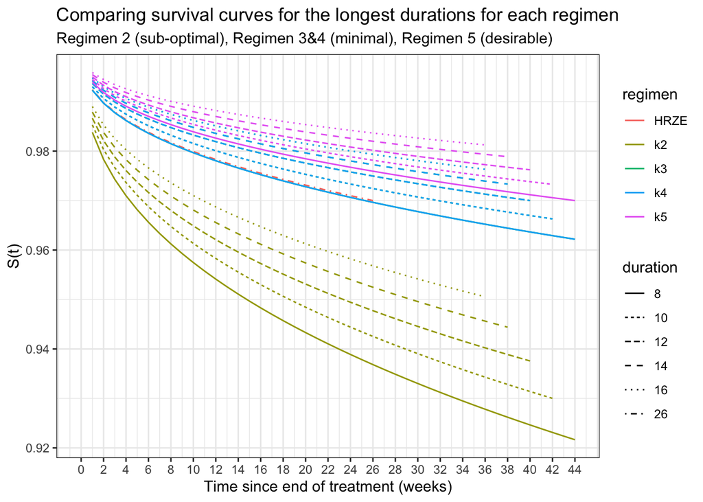

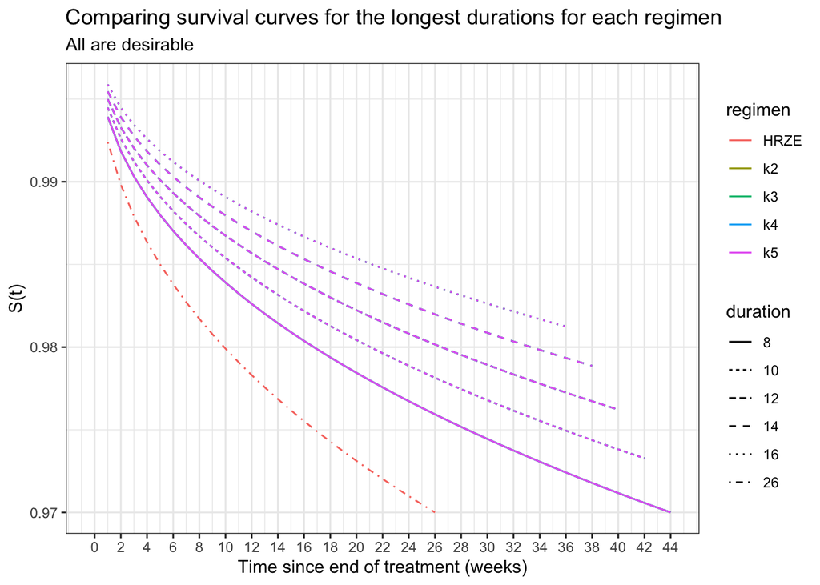

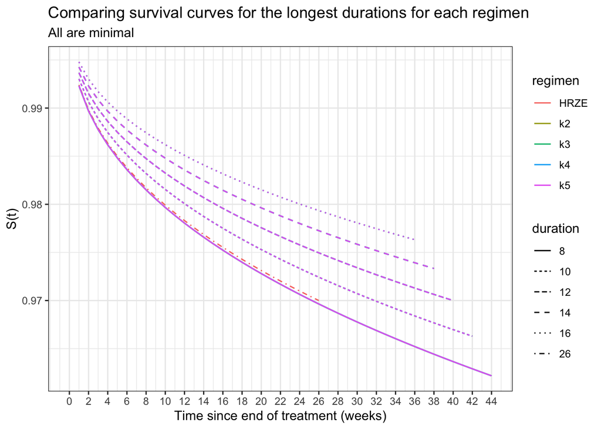

## Generated data

### Dataframe

First 3 observations for first 4 patients enrolled.

| patient.id | enroll.day | regimen | duration | patient.visit.day | patient.visit.week | yij | log10ttp.censored | yij_censored | interim1 |
| --- | --- | --- | --- | --- | --- | --- | --- | --- | --- |
| id1 | 1 | 3 | 8 | 0 | 0.00 | 0.66 | none | 0.66 | included |
| id1 | 1 | 3 | 8 | 9 | 1.29 | 0.89 | none | 0.89 | included |
| id1 | 1 | 3 | 8 | 14 | 2.00 | 0.97 | none | 0.97 | included |
| id2 | 1 | 3 | 16 | 0 | 0.00 | 0.94 | none | 0.94 | included |
| id2 | 1 | 3 | 16 | 5 | 0.71 | 1.25 | none | 1.25 | included |
| id2 | 1 | 3 | 16 | 14 | 2.00 | 1.29 | none | 1.29 | included |
| id3 | 3 | 5 | 10 | 0 | 0.00 | 0.57 | none | 0.57 | included |
| id3 | 3 | 5 | 10 | 7 | 1.00 | 0.62 | none | 0.62 | included |
| id3 | 3 | 5 | 10 | 12 | 1.71 | 0.87 | none | 0.87 | included |
| id4 | 3 | 4 | 14 | 0 | 0.00 | 1.00 | none | 1.00 | included |
| id4 | 3 | 4 | 14 | 6 | 0.86 | 0.86 | none | 0.86 | included |
| id4 | 3 | 4 | 14 | 12 | 1.71 | 0.88 | none | 0.88 | included |

### Data diagram

#### Randomization scheme

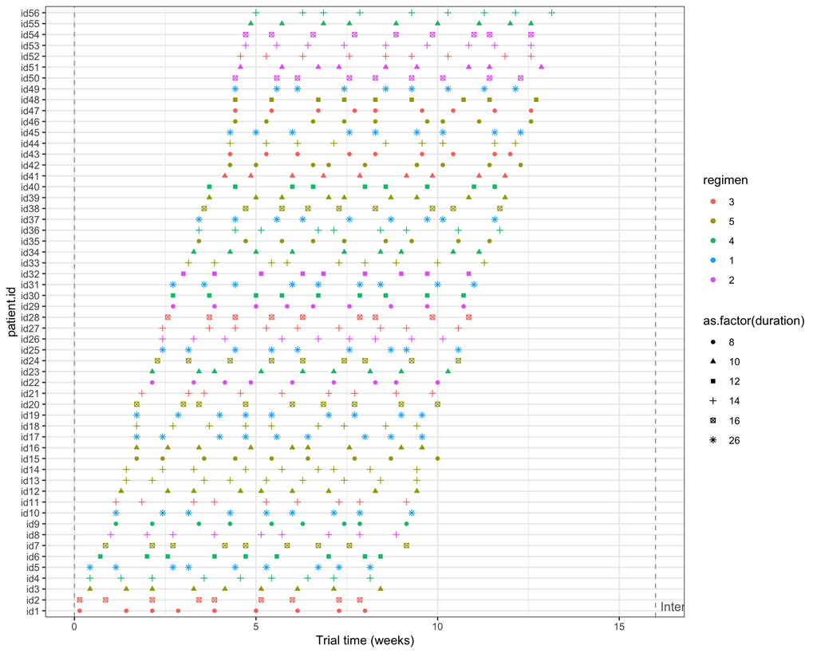

#### Visualization of Follow-up

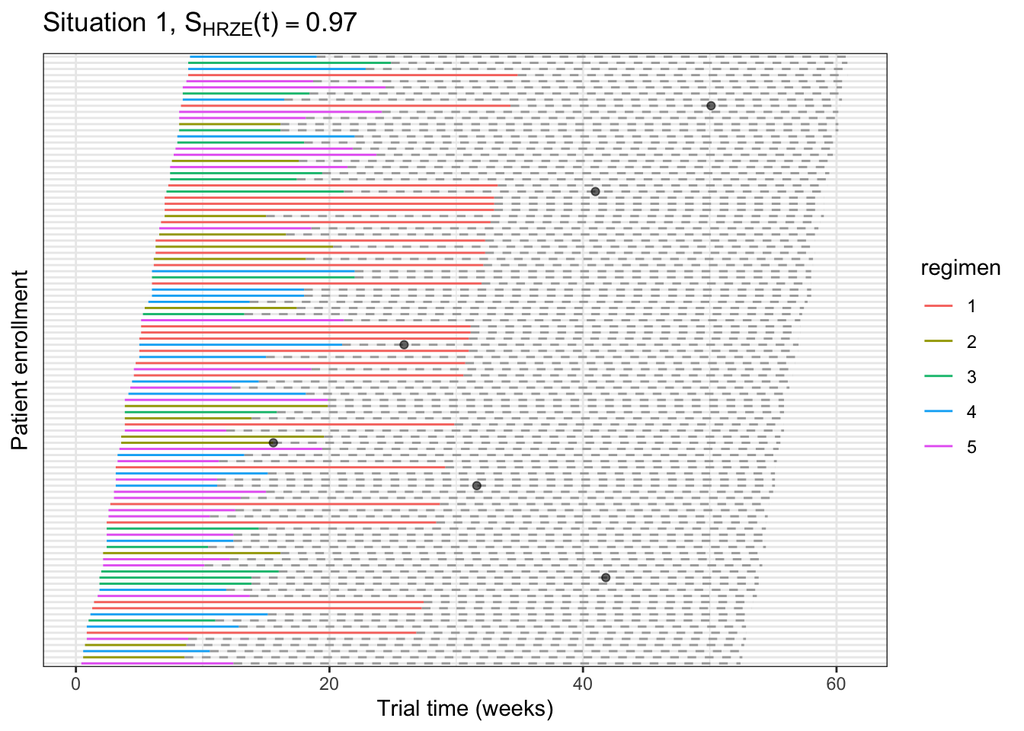

#### Visualizing when (observed) failure events occur

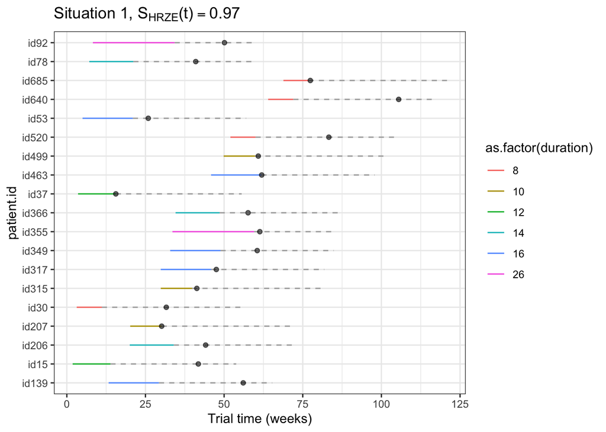

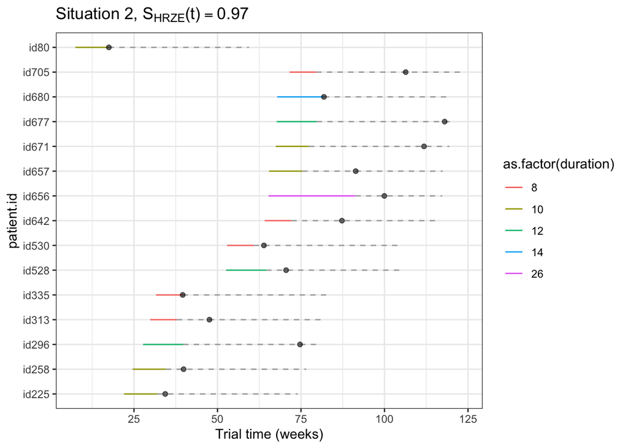

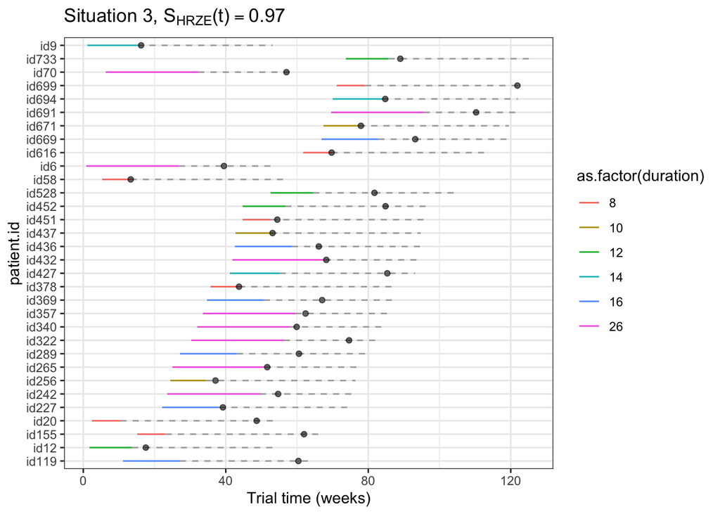